# IODS course project

Gintare Baublyte

# About the Course

This course is about open research tools with open data. It teaches how to use R, RStudio, RMarkdown, and GitHub to analyse data.

My Github repository https://github.com/gintarebaublyte/IODS-project

# Regression and Model Validation

This week I learned to wrangle data. Data wrangling are steps that need to be taken in order to process the data into more convenient format for its further analysis. Some of such steps could include combination of similar questions into one variable, scaling of some values back to their original values.

After the data was ready to be analysed, I learnt how to analyse the structure of it and how to look deeper into the different variables (see the avarage values, min, max, etc.). Graphical exploration of data is an important part of understanding the information that is in the dataset. It allows to look at the variables in regards to other variables, see the corelations and other information.

After getting a better picture of the variables that are in the dataset, I learnt how to choose an appropriate regression model to explain one dependant variable with one or multiple independant variables. Different information in the model summaries helps to indentify the best fitting model for the dataset. In addition to that, there is a number of diagnostic plots that can be utilized to explore the validity of model assumptions.

Overall, I learnt useful data analysis basics with R Studio.

## Data Structure

The dataset that will be analysed shows that there are 166 observations and 7 variables. Gender is recorded by assigning 1 and 2 for “female” and “male” respectively. Age is recorded as the actual age of the respondents. Questions related to attitude, deep learning, strategic learning and surface learning are evaluated in Likert scale (from 1 to 5). Points are the sum of points that students received from every exam question.

```
## 'data.frame':    166 obs. of  7 variables:
##  $ gender  : Factor w/ 2 levels "F","M": 1 2 1 2 2 1 2 1 2 1 ...
##  $ age     : int  53 55 49 53 49 38 50 37 37 42 ...
##  $ attitude: num  3.7 3.1 2.5 3.5 3.7 3.8 3.5 2.9 3.8 2.1 ...
##  $ deep    : num  3.58 2.92 3.5 3.5 3.67 ...
##  $ stra    : num  3.38 2.75 3.62 3.12 3.62 ...
##  $ surf    : num  2.58 3.17 2.25 2.25 2.83 ...
##  $ points  : int  25 12 24 10 22 21 21 31 24 26 ...
```

The dimensions fuction also shows that there are 166 rows (observations) and 7 columns (variables).

```
## [1] 166   7
```

## Graphical Overview and Summaries of Variables

The grapgh bellow shows how students’ attitude increases with higher points received in the exam. It seems that it’s quite similar for both genders.

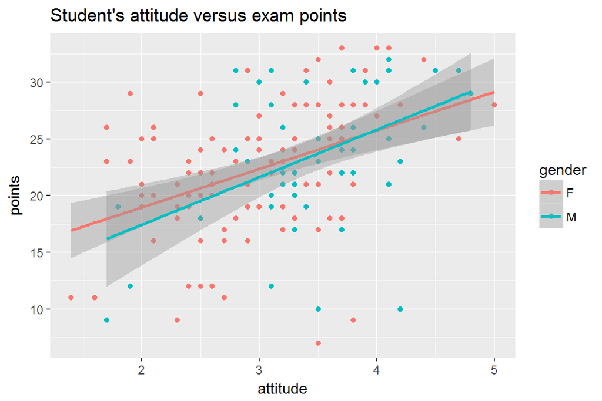

The gender variable shows that 110 students are female and 56 are male.

```
##   F   M
## 110  56
```

The average age of the students is 25.51 years old. The youngest respondent is 17 and the oldest 55 y.o.

```
##    Min. 1st Qu.  Median    Mean 3rd Qu.    Max.
##   17.00   21.00   22.00   25.51   27.00   55.00
```

The avarage value for attitude (which was measured in Likert scale (1-5)) is 3.143. Lowest value is 1.4 and the highest value is 5, which was also the highest possible value to choose from.

```
##    Min. 1st Qu.  Median    Mean 3rd Qu.    Max.
##   1.400   2.600   3.200   3.143   3.700   5.000
```

The avarage value assigned to questions related to deep learning was 3.68. The smallest value was 1.583 and the maximum 4.917.

```
##    Min. 1st Qu.  Median    Mean 3rd Qu.    Max.
##   1.583   3.333   3.667   3.680   4.083   4.917
```

The avarage value of answers to questions related to strategic learning is 3.121. Minimum value is 1.25 and the biggest one 5.

```
##    Min. 1st Qu.  Median    Mean 3rd Qu.    Max.
##   1.250   2.625   3.188   3.121   3.625   5.000
```

The avarage value of answers to questions related to surface learning is 2.787. Minimum value is 1.583 and the biggest one 4.333.

```
##    Min. 1st Qu.  Median    Mean 3rd Qu.    Max.
##   1.583   2.417   2.833   2.787   3.167   4.333
```

The avarage total points that students scored in the exam were 22.72. The lowest score was 7 and the highest 33. The middle value (or the median) was 23, which is almost the same as the average.

```
##    Min. 1st Qu.  Median    Mean 3rd Qu.    Max.
##    7.00   19.00   23.00   22.72   27.75   33.00
```

The grapgh bellow shows data on different variable pairs.

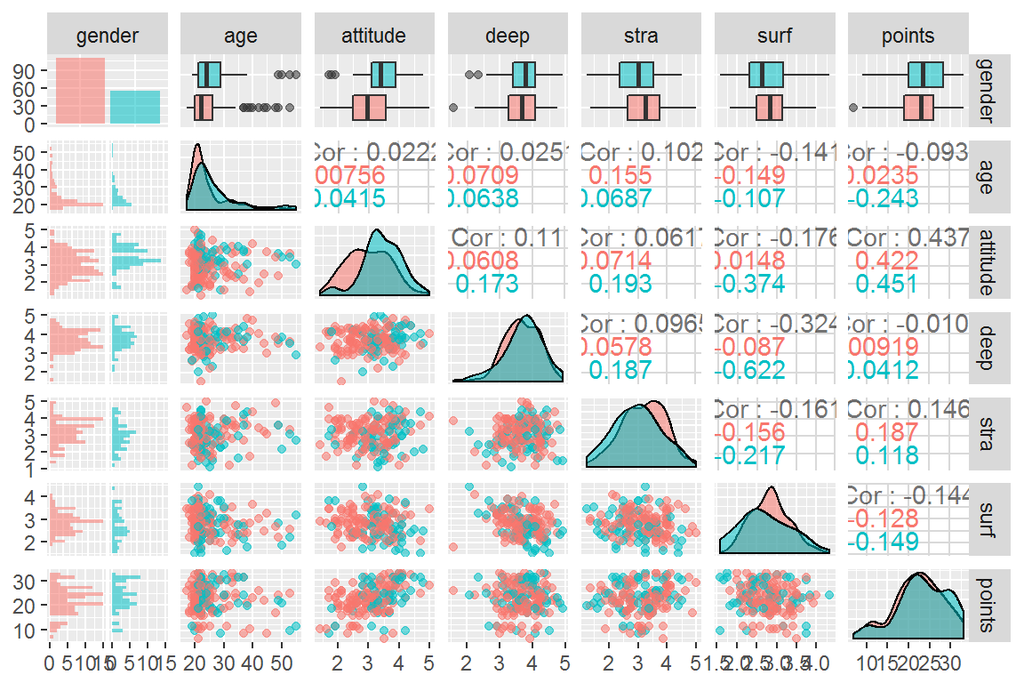

## Regression Model

Now a regression model will be chosen to explain the dependent variable, which is “points”.

The first regression model includes 3 variables to explain the dependant variable: 1) attitude, 2) surface learning, and 3) deep learning.

The statistical significance level (p value) for “attitude” is close to 0, which means that this variable is statistically significant in explaining the dependent variable. However, other two variables are statistically insignificant, thus, they need to be replaced.

```
##
## Call:
## lm(formula = points ~ attitude + surf + deep, data = students2014)
##
## Residuals:
##      Min       1Q   Median       3Q      Max
## -16.9168  -3.1487   0.3667   3.8326  11.3519
##
## Coefficients:
##             Estimate Std. Error t value Pr(>|t|)
## (Intercept)  18.3551     4.7124   3.895 0.000143 ***
## attitude      3.4661     0.5766   6.011 1.18e-08 ***
## surf         -1.0911     0.8360  -1.305 0.193669
## deep         -0.9485     0.7903  -1.200 0.231815
## ---
## Signif. codes:  0 '***' 0.001 '**' 0.01 '*' 0.05 '.' 0.1 ' ' 1
##
## Residual standard error: 5.313 on 162 degrees of freedom
## Multiple R-squared:  0.2024, Adjusted R-squared:  0.1876
## F-statistic:  13.7 on 3 and 162 DF,  p-value: 5.217e-08
```

The second regretion model includes 3 variables to explain the dependant variable: 1) attitude, 2) age, and 3) strategic learning.

The statistical significance level (p value) for “attitude” is close to 0, which means that this variable is statistically significant in explaining the dependent variable. However, other two variables are statistically insignificant (their values are more than 0.05), thus, they need to be replaced.

```
##
## Call:
## lm(formula = points ~ attitude + age + stra, data = students2014)
##
## Residuals:
##      Min       1Q   Median       3Q      Max
## -18.1149  -3.2003   0.3303   3.4129  10.7599
##
## Coefficients:
##             Estimate Std. Error t value Pr(>|t|)
## (Intercept) 10.89543    2.64834   4.114 6.17e-05 ***
## attitude     3.48077    0.56220   6.191 4.72e-09 ***
## age         -0.08822    0.05302  -1.664   0.0981 .
## stra         1.00371    0.53434   1.878   0.0621 .
## ---
## Signif. codes:  0 '***' 0.001 '**' 0.01 '*' 0.05 '.' 0.1 ' ' 1
##
## Residual standard error: 5.26 on 162 degrees of freedom
## Multiple R-squared:  0.2182, Adjusted R-squared:  0.2037
## F-statistic: 15.07 on 3 and 162 DF,  p-value: 1.07e-08
```

After testing a few other variations I have decided to choose linear regresion model with just one explanatory variable “attitude”, as only this variable was statistically significant in explaining the dependant variable.

```
##
## Call:
## lm(formula = points ~ attitude, data = students2014)
##
## Residuals:
##      Min       1Q   Median       3Q      Max
## -16.9763  -3.2119   0.4339   4.1534  10.6645
##
## Coefficients:
##             Estimate Std. Error t value Pr(>|t|)
## (Intercept)  11.6372     1.8303   6.358 1.95e-09 ***
## attitude      3.5255     0.5674   6.214 4.12e-09 ***
## ---
## Signif. codes:  0 '***' 0.001 '**' 0.01 '*' 0.05 '.' 0.1 ' ' 1
##
## Residual standard error: 5.32 on 164 degrees of freedom
## Multiple R-squared:  0.1906, Adjusted R-squared:  0.1856
## F-statistic: 38.61 on 1 and 164 DF,  p-value: 4.119e-09
```

From the summary of the regression model it can be seen that the intercept point is at 11.64, which is the alpha in the model. The beta is equal to 3.53 and it means that when attitude increases by 1, points increase by 3.53 if everything else remains the same.

The multiple R-Squared shows how well the chosed regression model fits the data. In this case multiple R-squared is equal to 0.1906 which is really low and would mean that the model doesn’t explain the given data well.